# Oslomet 23. oktober 2018

## Språkendring - diskurs og semantikk

```python
import module_update
from module_update import update
```

```
Updated file nbtext.py
Updated file nbpictures.py
```

```python
update('graph_networkx_louvain')
```

```
Updated file graph_networkx_louvain.py
```

```python
import nbtext as nb
import nbpictures as pct
import pandas as pd
import graph_networkx_louvain as gnl
from graph_networkx_louvain import make_collocation_graph
import networkx as nx
```

# Nasjonalbiblioteket og digitalisering

- Digitaliseringsarbeidet startet for alvor i 2006
- Metadata for bøker fra Nasjonalbibliografien, og nye metadataformat for nye medier, som film og lyd.
- Bokhylla-avtalen fra 2012. Alle bøker publisert før 2000 er tilgjengelig på nb.no
- Fra 2017 er bøkene også gjort tilgjengelig for forskning gjennom ikke-konsumerbar bruk

# Kunnskapsorganisering - semantisk eller diskursiv kunnskap

### Hva er kunnskap?

- [Wikipedia](https://en.wikipedia.org/wiki/Knowledge)
- [Stanford encyclopedia om epistemologi](https://plato.stanford.edu/entries/epistemology/)
- [Stanfor encyclopdia kunnskap](https://plato.stanford.edu/entries/knowledge-analysis/)

Her skal vi se litt på materialitet og gjøre en distinksjon mellom kunnskap og informasjon, som dels går på materialitet.

Det kan se ut som at informasjon har større grad av fysisk materialitet enn det kunnskap har. Her er noen grammatiske forskjeller på kunnskap og informasjon:

```
Informasjonen/?kunnskapen ble sendt med post.
Ola har informasjon/?kunnskap om at jorda er flat. (? fordi jorda ikke er det)
```

Kunnskap er tett knyttet til sannhet. Det å ha kunnskap, eller vite noe, impliserer sannhet (vite er et faktuelt verb) på samme måte som beklage:

```
Det at "Ola vet/beklager at det regner", betyr at det regner.
```

Kunnskap er også forskjellig fra informasjon - i tillegg til at informasjon kan være usann eller sann (på samme måte som påstander) vil kunnskap i større grad oppstå gjennom slutninger, pr.definisjon er kunnskap sann (så når noe rokker ved kunnskapen er det mye som ryker i samme slengen): samtidig som du får informasjon om en ting, kan du få kunnskap om mye mer:

Du vet at melken befinner seg i ett av tre kjøleskap A, B eller C, og du har fått verifisert informasjon om at den er i enten A eller B. Men nøyaktig i hvilket kjøleskap melken befinner seg vet du ikke, men om du får (verifisert) informasjon om at melken befinner seg i B eller C, kan du slutte deg til at melken befinner seg i B. Med slutninger kunnskapen der. Selv om det ikke er noen direkte informasjon om at melken er i B, får du kunnskapen ved å kombinere informasjonen fra to biter informasjon (eller kunnskap) (A eller B) og (B eller C). Kombinasjonen av tidligere kunnskap og informasjon gir ny *kunnskap* som ikke ligger i noen informasjonsbitene.

Mens informasjon kan flyttes, slettes, komme på avveie etc., har ikke kunnskap noen av de egenskapene. Selv ikke når kunnskapen og informasjonen har det samme innholdet, som når du får en lapp hvor det står at Galdhøpiggen er 2400 meter høy. Kunnskapen fra informasjonen er distinkt fra informasjonen selv. Om noen gir deg lappen, har du fått informasjonen, men kunnskapen har du ikke fått før du leser lappen og forstår den. Man kan godt si at "informasjonen er overført" etter å gitt noen en slik lapp, men du kan ikke uten videre si at "kunnskapen er overført" etter samme handling.

En annen grammatisk egenskap ved kunnskapsord ligger i nettopp måten den overføres på, at kunnskap har samme egenskap som hodepine i:

```
Han ga henne hodepine/kunnskap
*?Han ga hodepine/kunnskap til henne
```

I motsetning til informasjon og bøker, der

```
Hun ga barna bøker/informasjonen
```

er like bra som:

```
Hun ga bøker/informasjonen til barna
```

Så vi kan si at kunnskap er på en måte privat og konstitueres av den enkelte, mens informasjon er åpen og offentlig. Informasjon kan deles, kunnskap må skapes og gjenskapes.

# Metadata for objekter

Metadata er informasjon om objekter, og i seg selv et resultat av resonnementer. Metadata kan kombineres og kobles til seg selv, og kobles til innhold for å gi ny kunnskap og informasjon.

Metadata legges inn ved bibliotekene i forskjellige formater, for eksempel Marc21, og kan hentes ut fra digitale lager. For eksempel med [APIer](https://api.nb.no) fra Nasjonalbiblioteket. APIene er adgang til metadata for programmer og algoritmer, og brukes til å bygge brukergrensesnitt, som for eksempel [ORIA](https://oria.no)

### Språkbankens API mot metadata

```python
nb.get_urn({'author':"hamsun%knut%","year":1950, "next":50})
```

```
[[2013010408146, 'Hamsun, Knut', 'Markens grøde', 1972],
 [2008073100012, 'Hamsun, Knut', 'På gjengrodde stier', 1996],
 [2007051401028, 'Hamsun, Knut', 'Segelfoss by', 1967],
 [2009010704041, 'Hamsun, Knut', 'Samlede verker', 1997],
 [2009031900017, 'Hamsun, Knut', 'Sult', 1990],
 [2013030608007, 'Hamsun, Knut', 'Samlede verker', 1992],
 [2012092606142, 'Hamsun, Knut', 'Samlede verker', 1964],
 [2010081808019, 'Hamsun, Knut', 'Knut Hamsun', 1998],
 [2009010704135, 'Hamsun, Knut', 'Samlede verker', 2000],
 [2008082701033, 'Hamsun, Knut', 'Pan', 1998]]
```

### NBs api mot metadata som marc-xml

```python
nb.xmlpretty(nb.metadata_xml(2007051401028))
```

```
<?xml version="1.0" encoding="UTF-8" standalone="yes"?>
<html>
 <body>
  <record xmlns="http://www.loc.gov/MARC21/slim">
   <leader>
    nam  22     uu 4500
   </leader>
   <controlfield tag="001">
    997511476994702202
   </controlfield>
   <controlfield tag="003">
    nb.bibsys.no
   </controlfield>
   <controlfield tag="005">
    20170126162802.0
   </controlfield>
   <controlfield tag="008">
    140610
                        s
                            no#||||| |||||||||||nob||
   </controlfield>
   <datafield ind1=" " ind2=" " tag="040">
    <subfield code="a">
     NO-TrBIB
    </subfield>
   </datafield>
   <datafield ind1="1" ind2="0" tag="245">
    <subfield code="a">
     Segelfoss by
    </subfield>
    <subfield code="c">
     Knut Hamsun ; med en innledning av Edvard Beyer
    </subfield>
   </datafield>
   <datafield ind1="1" ind2=" " tag="700">
    <subfield code="a">
     Hamsun, Knut
    </subfield>
    <subfield code="d">
     1859-1952
```

[output cut: 196 more lines]

```
    <subfield code="i">
     Del av Bibliografien
    </subfield>
   </datafield>
   <datafield ind1="0" ind2=" " tag="773">
    <subfield code="t">
     Ibsensamlingen
    </subfield>
    <subfield code="i">
     Del av Bibliografien
    </subfield>
   </datafield>
  </record>
 </body>
</html>
```

### Informasjon om Dewey-systemet

Her er lenke til [Webdewey](http://deweysearchno.pansoft.de/webdeweysearch/index.html), ellers er det litt informasjon for programmet.

```python
nb.dewey(739)
```

```
{'1': ['7', 'Kunst og fritid'],
 '2': ['73', 'Skulptur; keramisk kunst og metallkunst'],
 '3': ['739', 'Metallkunst']}
```

```python
example = nb.urn_coll('hans',[2007051401028], before=4, after=4)
```

```python
example2 = nb.urn_coll('hendes',[2007051401028], before=4, after=4)
```

```python
book = nb.get_freq(2007051401028, top=0, cutoff=4)
```

```python
book = nb.frame(book, 'book')
```

```python
example[0][:10]
```

```
,       111
og       64
.        52
var      46
i        38
på       26
hans     22
det      20
for      20
han      20
Name: 0, dtype: int64
```

```python
example2[0][:10]
```

```
,      24
og     24
.      17
var    15
i      12
det    11
far     7
han     7
at      6
-       5
Name: 0, dtype: int64
```

```python
t = nb.frame(example[0]**1.3/book['book'], "relcoll").sort_values(by='relcoll', ascending = False)
```

```python
t2 = nb.frame(example2[0]**1.3/book['book'], "relcoll").sort_values(by='relcoll', ascending = False)
```

```python
t.join(example.join(book))[:15]
```

|  | relcoll | 0 | book |
| --- | --- | --- | --- |
| utseende | 0.834234 | 3.0 | 5.0 |
| ansigt | 0.738208 | 7.0 | 17.0 |
| kone | 0.622022 | 8.0 | 24.0 |
| ører | 0.492458 | 2.0 | 5.0 |
| person | 0.492458 | 2.0 | 5.0 |
| hode | 0.466374 | 4.0 | 13.0 |
| øine | 0.464797 | 7.0 | 27.0 |
| møtt | 0.410381 | 2.0 | 6.0 |
| kamerater | 0.410381 | 2.0 | 6.0 |
| slægt | 0.410381 | 2.0 | 6.0 |
| far | 0.396219 | 11.0 | 57.0 |
| forhold | 0.351756 | 2.0 | 7.0 |
| søn | 0.336826 | 4.0 | 18.0 |
| hans | 0.279445 | 22.0 | 199.0 |
| bedste | 0.273588 | 2.0 | 9.0 |

```python
t2.join(example2.join(book))[:15]
```

|  | relcoll | 0 | book |
| --- | --- | --- | --- |
| ærend | 0.347597 | 3.0 | 12.0 |
| øine | 0.224551 | 4.0 | 27.0 |
| mund | 0.223844 | 2.0 | 11.0 |
| far | 0.220167 | 7.0 | 57.0 |
| snu | 0.200000 | 1.0 | 5.0 |
| urlite | 0.200000 | 1.0 | 5.0 |
| bænk | 0.200000 | 1.0 | 5.0 |
| nikke | 0.200000 | 1.0 | 5.0 |
| hår | 0.200000 | 1.0 | 5.0 |
| ført | 0.200000 | 1.0 | 5.0 |
| lukke | 0.200000 | 1.0 | 5.0 |
| kjøre | 0.200000 | 1.0 | 5.0 |
| større | 0.189407 | 2.0 | 13.0 |
| billede | 0.166667 | 1.0 | 6.0 |
| tårer | 0.166667 | 1.0 | 6.0 |

```python
def show_graph(G, spread=0.2, fontsize=10, deltax=0.04, deltay=0.04):
    return gnl.draw_graph_centrality2(G, gnl.mcommunity(G),k = spread, fontsize=fontsize, deltax=deltax, deltay=deltay)
```

```python
def show_cliques(G):
    C = gnl.make_cliques_from_graph(G.to_undirected())
    for t in C[1]:
        print(t, ', '.join(C[1][t]))
        print()

def show_community(G):
    MC = gnl.mcommunity(G)
    for i in range(len(MC)):
        print(i + 1, ', '.join(MC[i]))
        print()
```

```python
G = nb.make_graph('pålegg')
```

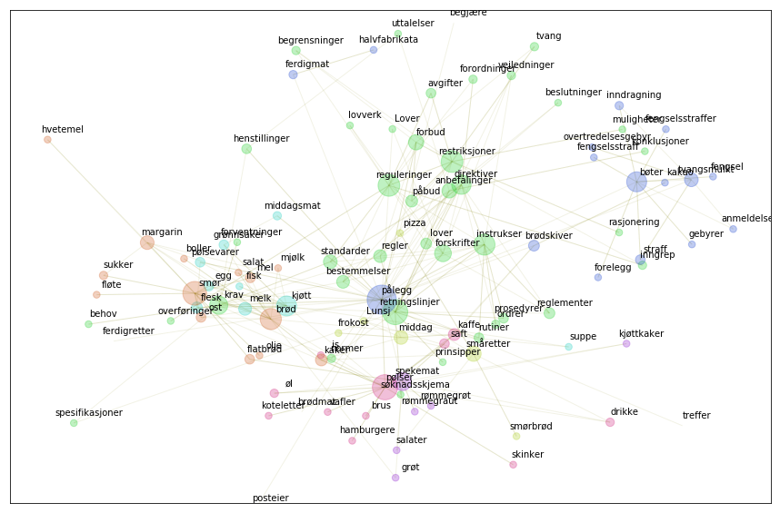

```python
show_graph(G, spread=1.2)
```

```python
show_cliques(G)
```

```
(3, 1) standarder, veiledninger, direktiver, begrensninger, pålegg, bestemmelser, avgifter, lovverk, restriksjoner, retningslinjer, anbefalinger, normer, prosedyrer, påbud, krav, ordrer, lover, reglementer, reguleringer, regler, forskrifter, henstillinger, spesifikasjoner, rutiner, forbud, instrukse…

(3, 2) kjøtt, pølsevarer, pålegg, pølser, flesk, margarin, brød, ost, hvetemel, melk, smør, egg, kaker, mel, sukker

(3, 3) tvangsmulkt, bøter, straff, pålegg, inndragning, anmeldelse

(3, 4) Lunsj, småretter, kaker, pålegg, middag

(4, 1) veiledninger, standarder, direktiver, reglementer, lover, pålegg, bestemmelser, regler, forskrifter, instrukser, retningslinjer

(4, 2) påbud, pålegg, reguleringer, restriksjoner, forbud, begrensninger

(4, 3) pålegg, margarin, brød, melk, smør, mel

(5, 1) direktiver, reglementer, pålegg, forskrifter, instrukser, retningslinjer
```

```python
show_community(G)
```

```
1 middag, smørbrød, pizza, Lunsj, småretter, frokost

2 standarder, veiledninger, direktiver, behov, avgifter, muligheter, beslutninger, konklusjoner, krav, overføringer, ordrer, reglementer, lover, reguleringer, uttalelser, søknadsskjema, rutiner, påbud, instrukser, tvang, rasjonering, lovverk, restriksjoner, retningslinjer, normer, forventninger, anb…

3 kjøtt, pølsevarer, fisk, flesk, suppe, middagsmat, melk, grønnsaker, egg

4 brødmat, bøter, ferdigmat, anmeldelse, tvangsmulkt, halvfabrikata, gebyrer, ferdigretter, brødskiver, kakao, fengselsstraffer, treffer, posteier, straff, pålegg, inndragning, begjære, overtredelsesgebyr, fengsel, forelegg, fengselsstraff

5 rømmegrøt, grøt, rømmegraut, spekemat, salater, kjøttkaker

6 saft, drikke, skinker, pølser, koteletter, øl, brus, hamburgere, kaffe, is, vafler

7 salat, flatbrød, margarin, ost, hvetemel, mjølk, brød, fløte, smør, olje, kaker, mel, sukker, boller
```

```python
G_is = nb.make_graph('is')
```

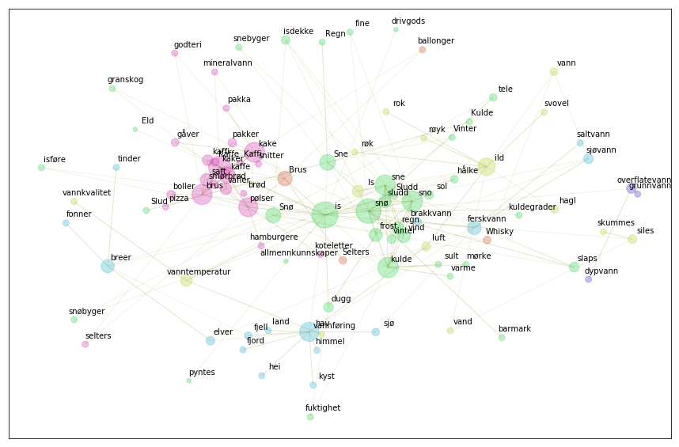

```python
show_graph(G_is, spread=1.2)
```

```python
show_cliques(G_is)
```

```
(3, 1) sne, snø, vinter, vind, hålke, sludd, ild, Snø, breer, slaps, is, kuldegrader, Sludd, frost, kulde, sol, regn, Sne, sno, fine, isdekke

(3, 2) elver, sjøvann, is, ferskvann, brakkvann, hav, sjø

(3, 3) saft, smørbrød, Kaffe, mineralvann, kake, pølser, Brus, brød, brus, kaffi, kaffe, kaker, is, vafler, boller

(4, 1) sne, frost, snø, kulde, vinter, vind, regn, is, sno

(4, 2) saft, kake, pølser, brus, kaffe, kaker, is, vafler, Brus

(5, 1) saft, kake, pølser, brus, kaffe, kaker, is, vafler, Brus
```

```python
show_community(G_is)
```

```
1 røyk, vann, vanntemperatur, svovel, rok, luft, hagl, røk, siles, vannføring, skummes, ild, Is, vannkvalitet, vand

2 snøbyger, snø, sult, pyntes, dugg, drivgods, vinter, vind, hålke, sludd, is, Snø, allmennkunnskaper, kuldegrader, Regn, tele, Vinter, Slud, sol, granskog, Sne, barmark, snebyger, fuktighet, sno, fine, varme, sne, Kulde, isføre, slaps, Sludd, Eld, frost, kulde, regn, mørke, isdekke

3 fonner, kyst, hav, himmel, hei, fjell, saltvann, fjord, elver, tinder, sjøvann, breer, ferskvann, brakkvann, land, sjø

4 overflatevann, dypvann, grunnvann

5 hamburgere, kaffe, smørbrød, pakka, pølser, brød, Kaffi, pakker, selters, snitter, pizza, koteletter, godteri, kaffi, kake, kaker, vafler, saft, gåver, mineralvann, Kaffe, brus, boller

6 ballonger, Whisky, Selters, Brus
```

```python
mat = nb.get_urn({'ddk':"641%", 'limit':40, 'lang':'nob'})
```

```python
mat
```

```
[[2012102208075,
  'Dege, Hroar',
  'Christopher Hammer: Norsk Kogebog, 1793',
  1994],
 [2007111504007,
  'Bang, Karen Dorothea',
  'Fuldstændig norsk kogebog til brug såvel i større som mindre husholdninger',
  1991],
 [2010032612004,
  'Petersen-Schepelern, Elsa',
  'Gelati, iskrem og sorbet',
  1998],
 [2012062205040, 'Prent, Tom', 'Vinboken', 1988],
 [2010041503003, 'Willan, Anne', 'Matgleder', 1996],
 [2008101304043, 'Clarke, Oz', 'Nybegynnerens vinbok', 2000],
 [2011060606084, 'Borgen, Annemarta', 'Fisk fra kjøkkenet på Knatten', 1983],
 [2008052000061, 'Dege, Hroar', 'Mat for venner', 1964],
 [2013021538053, 'Salaman, Rena', 'Liten gresk kokebok', 1994],
 [2014032408161, 'Erken, Lillemor', 'Tidens bakebok', 1962],
 [2016020907657, '', 'Sild', 1983],
 [2008112000035, 'Carpenter, Hugh', 'Hot pasta', 1999],
 [2010043003025, 'Dimbleby, Josceline', 'Så godt som grønt', 1995],
 [2013050707072, '', 'Matglede', 1984],
 [2014051508042, '', '"Mysengryta"', 1990],
 [2014080508156, 'Olaf-Hansen, Erik', 'Drikk vin', 1986],
 [2015021048082, 'Leah, Diane', '100 velsmakende slankeretter', 1987],
 [2016011348080, '', 'Sausboken', 1988],
 [2010090703003, 'Kumar, Marcela', 'India', 1996],
 [2010082703020, 'Tidehorn, Annika', 'Det gode hete', 1998],
 [2010071203010, 'Goldstein, Joyce', 'Middelhavet', 1997],
 [2010041603027, 'Bogø, Jette', 'Lyng og honning', 1998],
 [2015030606015, 'Kåsin, Britt', 'Alle sju slaga', 1984],
 [2010041203061, '', 'Iskrem', 1999],
 [2016031548060, '', 'Gyldendals store kokebok', 1955],
 [2014070807034, 'Westland, Pamela', 'smak av greske øyer', 1994],
 [2016101048184, 'Hale, Sophie', 'store hvitløkkokeboken', 1987],
 [2016062748164,
  '',
  'Norsk ukeblads store bok om smørbrød og smørbrødkaker',
  1986],
 [2011111508025, '', 'Det nye kjøkkenbibliotek', 1971],
 [2009070204075, 'Hovig, Ingrid Espelid', 'Hverdagsmat', 1996],
 [2016101448013, 'Klamerholm, Aslaug Fjørstad', 'Kokebok', 1957],
 [2008071600057, 'Hovig, Ingrid Espelid', 'Ingrids minste', 1996],
 [2010110320005, '', 'Raske retter', 1990],
 [2011121608005, '', 'Grønnsakretter', 1956],
 [2011082906015, 'Kåsin, Britt', 'Britt Kåsins store eggebok', 1984],
 [2010060803042, 'Walker, Michael', 'Cocktails', 1995],
 [2010090703010, 'Gordon-Smith, Clare', 'Med smak av eddik', 1997],
 [2010042203019, 'Olesen, Anemette', 'Blomster på menyen', 1996],
 [2010060203008, '', 'Meksikansk kokebok', 1996],
 [2016030248096, 'Hale, Sophie', 'store hvitløkkokeboken', 1991]]
```

```python
I = nb.urn_coll('is', urns=mat, before=4, after=4)
```

```python
Ig = nx.Graph()
Ig.add_edges_from([('is', w) for w in I[:20].index])
```

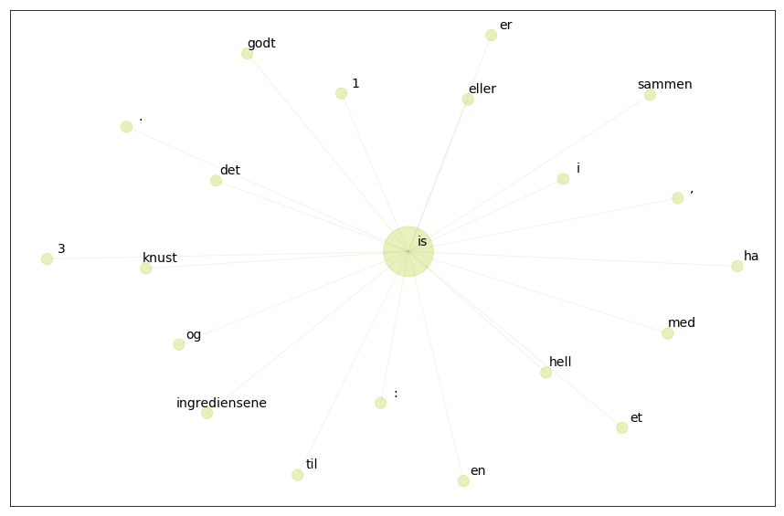

```python
show_graph(Ig, fontsize=14, spread=0.03)
```

```python
from collections import Counter
antall = Counter()
for urn in mat:
    antall += nb.get_freq(urn[0], top=0, cutoff=0)
```

```python
korpus_totalen = nb.frame(antall, 'total')
Total = korpus_totalen[korpus_totalen > 20]
```

```python
toppIce = nb.frame(I[0]**1.2/Total['total'], 'is').sort_values(by='is', ascending=False)
```

```python
Ig1 = nx.Graph()
Ig1.add_edges_from([('is', w) for w in toppIce[:20].index])
```

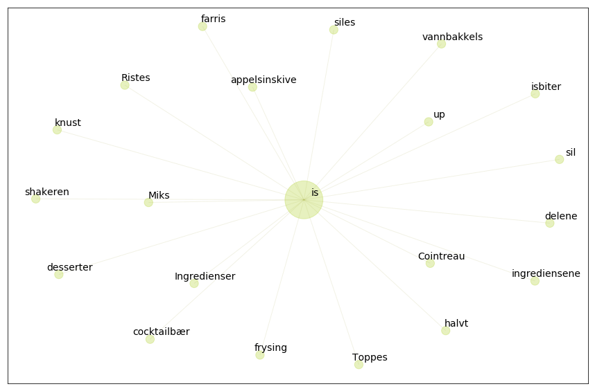

```python
show_graph(Ig1, fontsize=14, spread=0.03)
```

```python
from collections import Counter
antall = Counter()
for urn in mat:
    antall += nb.get_freq(urn[0], top=0, cutoff=0)
```

```python
korpus_totalen = nb.frame(antall, 'total')
Total = korpus_totalen[korpus_totalen > 10]
```

```python
Ice = make_collocation_graph('is', urns=mat, top = 20, before=8, after=8)
```

```python
show_community(Ice)
```

```
1 Rist, dekoreres, Midori, flyte, dash, sitronjuice, Ul, is, unntatt, dasher, ananasjulce, massevis, garnert, ake, nektar, Galliano, skvett, Miks, ingrediensene, steeges, Calvados, Bourbon, vinglass, champagnen, Toppes, Bitter, dråpe, whiskyglass, grenadine, Benedictine, cacao, champagne, kirsebærii…

2 orange, tomatsaft, rystes, løksaft, silen, stenk, ananasbiter, fruktsaft, COCKTAIL, Rystes, beskytte, Ryst, vermut, gin, ananassaft, sukkerbit, Old, nypresset, brandy, shakeren, Marnier, kulde, eplesaft, granateplesaft, Alkoholfri, fasonger, gjeme, grep, appelsinsaft, Røres

3 Martini, rocks, motsatte, Pyntes, bananskiver, York, bar, sil, up, papaya, pyntet, fortynnes, ber, drink, the, res, straight, vise, trekantet, kvart, forsøke, Golden, besto, Siles, cocktailglass, måtehold, siles, on

4 knust, farris, cocktailen, cocktailpinne, aprikos, glass, avkjøle, Fyll, shaker, Black, selters, halvt, Oppbevaring, sitronskive, cocktailbær, kirsebær, cocktails, beholder, appelsinskive, vridd, mehs, sviske, Plasser, mineralvann

5 soda, toppes, isbiter, pjolterglass, Ekstra, limonade, Helles, champagneglass, Topp, stort, trekant, limejuice, appelsinjuicen, isterninger, plasseres, stetteglass, Avslutt, etterfulgt, ananasskiver

6 dypfryseren, Pålegg, Tunge, Hare, Htt, spann, btt, varen, flyttes, voksbønner, pakkes, innpakket, frysemaskin, frysing, Pikant

7 Drikker, kutte, TI, Klassisk, fryseform, mang, snerk, løksuppe, Ingredienser, tillaging, desserter, em, Iskrem, veres, iskrem

8 Collins, Parfait, appelsinjuice, konjakk, tequila, Curacao, Brandy, Canada, Hvit, mål, Cointreau, Sec

9 Smørkrem, wienerbrød, Suppetilbehør, vafler, ostestenger, fingertykke, øyeblikket, ostekjeks, innbakt, Heller, vannbakkels
```

```python
show_cliques(Ice)
```

```
(3, 1) Martini, soda, rocks, Rist, pjolterglass, drink, the, champagneglass, straight, appelsinskive, kvart, res, dash, sitronjuice, Toppes, whiskyglass, Golden, Pyntes, is, Siles, cocktailglass, York, limonade, up, shaker, delene, papaya, siles, Ristes, pyntet, on

(3, 2) dash, Ristes, Bitter, Cointreau

(3, 3) eplesaft, Rystes, nypresset, granateplesaft, ananassaft, stenk, vermut, Alkoholfri, is, shakeren, COCKTAIL

(4, 1) Rystes, shakeren, nypresset, COCKTAIL

(4, 2) rocks, Siles, cocktailglass, the, straight, up, appelsinskive, kvart, on, Pyntes

(5, 1) rocks, cocktailglass, straight, appelsinskive, up, Pyntes
```

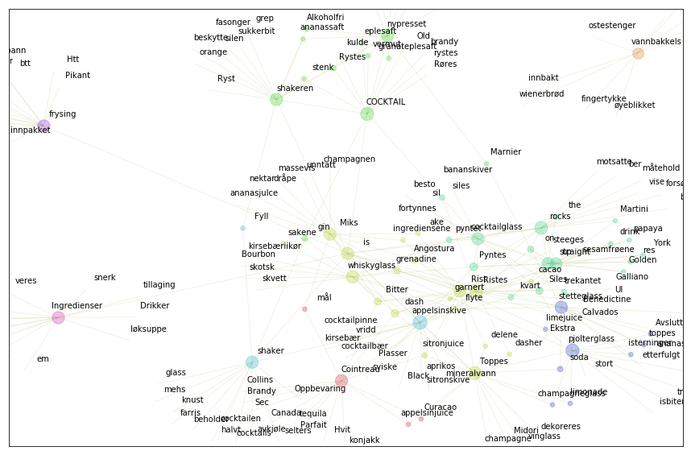

```python
show_graph(Ice, spread=0.16)
```

```python
Fisk = make_collocation_graph('fisk', urns=mat)
```

```python
show_cliques(Fisk)
```

```
(3, 1) grillstekt, smultkokt, fisk, skalldyr
```

```python
show_community(Fisk)
```

```
1 økonomisk, Kald, fjærfe, fc, Hl, fr, Kjøtt, vilt, fisk, typer

2 samt, kokt, kyllingene, grønnsak, Brukes, stekt, fugl, Pynt, gratenger, Majones, kakepapir, smultkokt

3 Smørbrød, Bouillabaisse, Pasta, skalldyr, delikatesser, Fiskegrateng, scampi, Fritert, LAKS

4 røkt, Krydret, Eplegelé, Lever, Florentine, verde, Lasagne, rekesaus, Ragu, tradisjonell, Kjøttsaus, Lam, rømmesaus, Pizza, kantareller

5 knuses, solid, Kål, mildere, hjertet, småfisk, bruken, Nederst, skyllet, Hel, mage, Helstekt, ovnsstekt, uendelig, eddiklake, svartpepper

6 tournedos, kalde, smørbrød, kjøttretter, kalvebrissel, Sausen, luftige, supper, kroketter, eggeretter, Sauce, utmerket, tillaging, makaroni

7 fiskefilé, stuing, oksebryst, fiskestykkene, dypfrossen, kyllinglever, spinat, porsj, Fiskeboller, pose, Stekt, Grateng, pk

8 krokettene, hende, rødspette, svakere, stekespade, piff, lysebrunt, griljert, Lekker, Ferdig, frysedisken, hamburgere, fryst, panert, etteråt

9 Svinekjøtt, Skinke, hvitting, Muskat, ribbe, svor, mager, Leverpostei, svinekoteletter, Svinestek, dårligere, akkompagnement, Skive, smelteost, risiko, bein

10 grillet, Fasta, Kaldt, Garnityr, kjøtt, Dypfryst, rødt, fjærkre, kot, rått, Malt, bulgur, Ferskt

11 september, Hvit, Hyse, Italiensk, fisker, gratinert, aspargestopper, au, kjøttsaus, februar, SKIVER, røkes, fiskefarse

12 svarte, anbefales, Istedenfor, fantes, Hvelv, Røket, slag, masse, overflate, sitte, feta, glinsende, tørt, Tilbered, kasser, minutt

13 riflete, frites, Ostesmør, vafler, ansjossaus, grille, grillstekt, sautert, aux, geit

14 gelatin, renset, frøene, klippfisk, bindes, loff, Klippfisk, karamellsaus, Loff, aprikos, oppløst, utbløtt, kg

15 Gravlaks, sennepssaus, nedlagte, laks, åla, Røkt, gravet, Melboestad, ørret, persisk
```

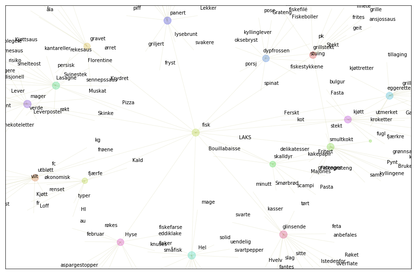

```python
show_graph(Fisk)
```

```python
vei = nb.get_urn({'ddk':"625%", 'limit':30, 'lang':'nob'})
```

```python
vei
```

```
[[2011052308078, 'Holøs, Bjørn', 'Bergensbanen 75', 1984],
 [2011121608045, '', 'Helårsvegen over Haukeli', 1957],
 [2008052204064,
  'Lærum, Ole Didrik',
  'Grunnkurs i veg- og jernbanebygging',
  1959],
 [2012050908181, '', 'Norsk vegmuseum til år 2000', 1994],
 [2008060304025, '', 'Underbygning', 1973],
 [2014070705124, 'Sando, Svein', 'Modelljernbane på norsk', 1992],
 [2012080108024, '', 'Miljøutredning', 1989],
 [2014070305017, 'Berger, Asle', 'Massedisponering', 1978],
 [2007071100049, 'Fjeld, Finn C', 'Skogsveger', 1974],
 [2013042438003, '', 'Fra kjerreveg til vegplan', 1988],
 [2008052204063,
  'Lærum, Ole Didrik',
  'Grunnkurs i veg- og jernbanebygging',
  1959],
 [2009112404124, '', 'Laboratorieundersøkelser', 1997],
 [2012061106049, 'Riise, T. B.', 'Vegbygging', 1966],
 [2014100608092, 'Irgens, Johannes B.', 'vegmanns erindringer', 1983],
 [2015021048033, '', 'Til Gosen via Sibirien', 1993],
 [2012041908129, 'Norem, Harald', 'Snøvern', 1972],
 [2009102800060, 'Grasmo, Jon O.', 'Vegvedlikehold', 1991],
 [2009101604018, 'Møyner, Kari', 'Gamle veger og vegfar', 1994],
 [2008060301030, 'Levik, Kjell', 'Vegvedlikehold', 1984],
 [2009101900090, 'Grasmo, Jon O.', 'Vegbygging', 1995],
 [2011092708007, 'Bjerke, Thor', 'På togtur med Dancker-Jensen', 1997],
 [2013062608053, '', 'Generell vegbygging', 1978],
 [2014073006066, 'Stokkebø, Stein Håvard', 'Armert jord', 1989],
 [2012080108011, '', 'Miljøutredning', 1989],
 [2012071208025,
  '',
  'Forhandlinger ved Nordisk vegteknisk forbunds 6. kongress i Norge 14.-20. juni 1954 =',
  1955],
 [2013061706001, 'Fossheim, Jens', 'Anleggsdrift', 1979],
 [2012022308196, 'Fossheim, Jens', 'Anleggsdrift', 1972],
 [2008102100056,
  '',
  'Retningslinjer for utførelse av bituminøse vegdekker og bærelag',
  1980],
 [2014052308026,
  'Engstrøm, Jan Erik',
  'Analyse av noen faktorer som påvirker anleggskostnadene for veger =',
  1979],
 [2007112604029, 'Berg, Jørgen Seemann', 'Damplokomotivets siste dager', 1991]]
```

```python
RoadIce = make_collocation_graph('is', urns=vei)
```

```python
show_community(RoadIce)
```

```
1 LL, SI, LU, sykkelveger, CNJ, CC, IM, SC, Seiv, is

2 jevnlig, raskere, isen, smelte, noenlunde, far, Får, vanskeligere, tildekket, gammelt, hensikten, begynner, resten, Hold

3 fremstilles, skjøten, smeltevannet, jordmassene, asfalten, smelter, telen, langsomt, Salt, røret, maskinelt, Tillatte, Flere

4 fester, opplasting, kornet, snø, dras, brøytes, fastere, ryddet, Lukket, tele, vinden, brøytekanter, samle

5 seinere, bestå, framkommer, binder, teleskorpa, hullet, naturgrus, Hele, islag, Sammensetningen, vanning, lufta, holder, rein

6 construction, and, costs, terrain, plan, the, Of, The, In, in, of, program, Institute, Determination, are, on

7 genom, mera, inte, trafikens, någon, mitt, dår, material, pa, positiv, detta, fore, Genom, inverkan

8 vågar, sno, Inntil, pakker, brukar, bygde, november, åpnes, slitedekke, forsok, Hallingdal, stenges, regn, stengt, våg

9 forhindre, løp, trauet, isolerte, stikkrennene, strøsand, hindres, fryser, vannavløpet, pelene, jorda, montere, fyllmassene, Stikkrenner, teleskytende

10 laste, basis, be, method, Peder, senter, ooo, as, Trykk, joner, æ

11 wet, lystekniske, våt, Sammenhengen, Vegdekke, prov, Is, prøvestykkets, Matjord, lunta, los, friktionen, Tørr, densitet

12 bekker, murens, deformasjon, dekket, interesse, vind, Enkel, bølger, grunnvann, tung, overflatevann, lager, utsettes, fundamenter, beskyttes, spesiell
```

```python
show_cliques(RoadIce)
```

```
(3, 1) construction, and, costs, terrain, Of, the, The, of, is

(3, 2) is, rein, snø
```

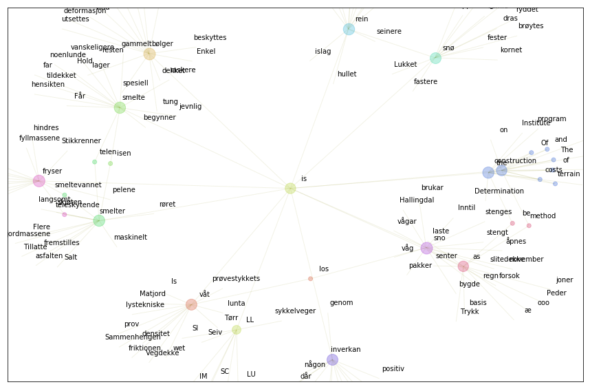

```python
show_graph(RoadIce)
```